# EDA-Challenge

Sarah

2024-02-06

#Load packages

```r
library("tidyverse")
library(dplyr)
```

#Bring in data

```r
f <- "https://raw.githubusercontent.com/difiore/ada-2024-datasets/main/data-wrangling.csv"
d <- read_csv(f, col_names = TRUE)
names(d)
```

```
##  [1] "Scientific_Name"         "Family"
##  [3] "Genus"                   "Species"
##  [5] "Brain_Size_Species_Mean" "Body_mass_male_mean"
##  [7] "Body_mass_female_mean"   "MeanGroupSize"
##  [9] "AdultMales"              "AdultFemale"
## [11] "GR_MidRangeLat_dd"       "Precip_Mean_mm"
## [13] "Temp_Mean_degC"          "HomeRange_km2"
## [15] "DayLength_km"            "Fruit"
## [17] "Leaves"                  "Fauna"
## [19] "Canine_Dimorphism"       "Feed"
## [21] "Move"                    "Rest"
## [23] "Social"
```

#Create Body Size Dimorphism (BSD) column.

```r
d <- mutate(d, BSD = (d$Body_mass_male_mean/d$Body_mass_female_mean))
```

#Create Sex Ratio column

```r
d <- mutate(d, Sex_Ratio = (d$AdultFemale/d$AdultMales))
```

#Create Defensibilty Index (DI) column (day range length/diameter of home range)

```r
d <- mutate(d, DI = (d$DayLength_km/((sqrt(d$HomeRange_km2/pi))*2)))
```

#Plot Day Length vs. Time Moving overall. I will also log transform the data.

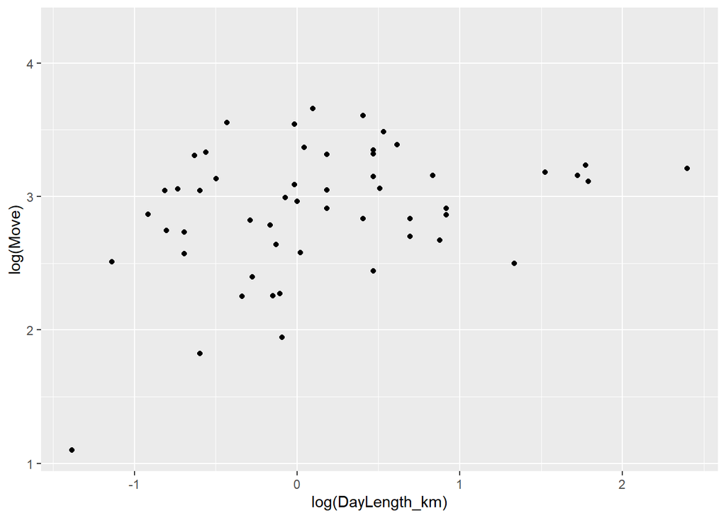

```r
s<-ggplot(data=d, aes(x=log(DayLength_km), y=log(Move)))
  s+geom_point(na.rm = TRUE)
```

#Plot Day Length vs Time Moving for each family. I will continue to log transform the data

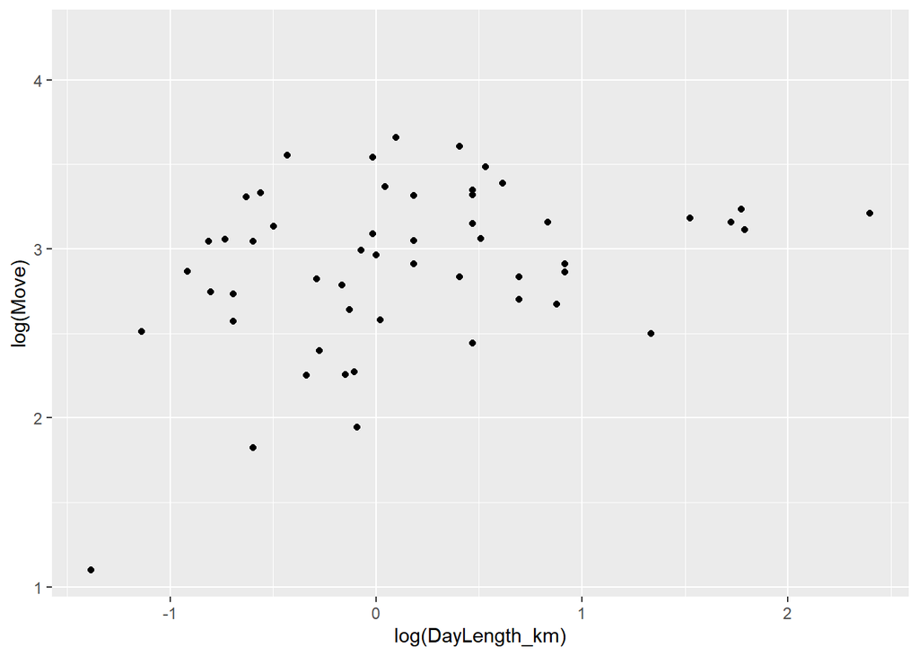

```r
s<-ggplot(data=d, aes(x=log(DayLength_km), y=log(Move)))
  s+geom_point(na.rm = TRUE)
```

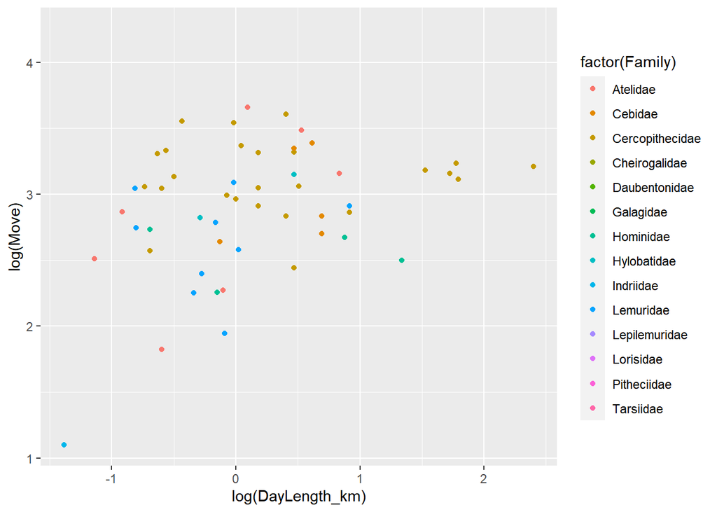

```r
  s+geom_point(aes(color=factor(Family)), na.rm = TRUE)
```

Species that move around more travel farther. Cercopithecidae appear to travel the farthest.

#Plot Day Length vs group size. Log transform the data.

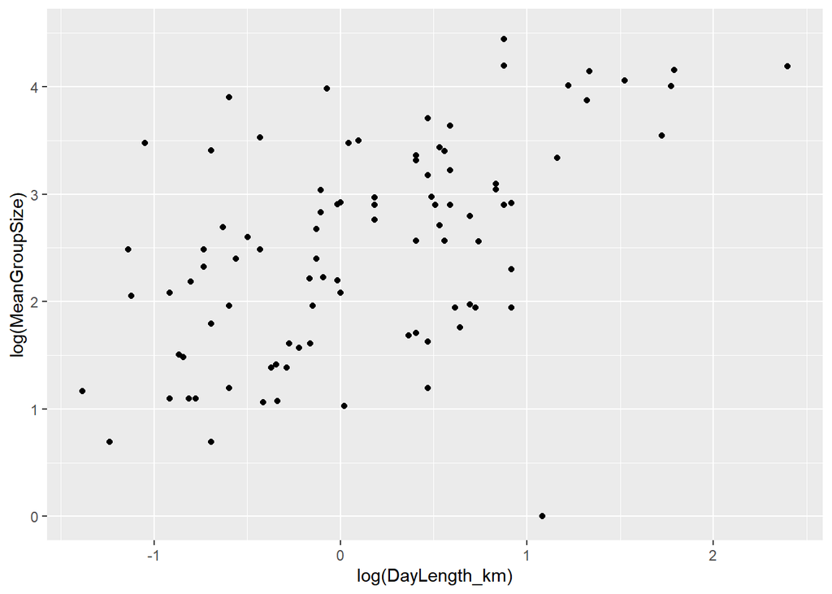

```r
s<-ggplot(data=d, aes(x=log(DayLength_km), y=log(MeanGroupSize)))
  s+geom_point(na.rm = TRUE)
```

#Plot Day Length vs group size separated by family

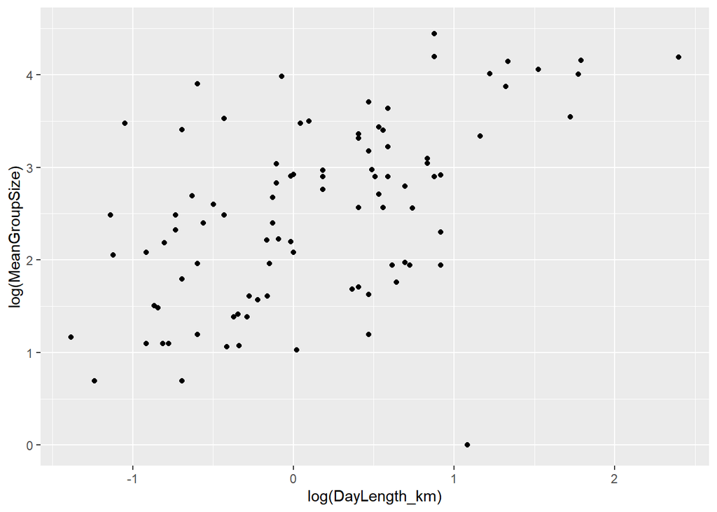

```r
s<-ggplot(data=d, aes(x=log(DayLength_km), y=log(MeanGroupSize)))
  s+geom_point(na.rm = TRUE)
```

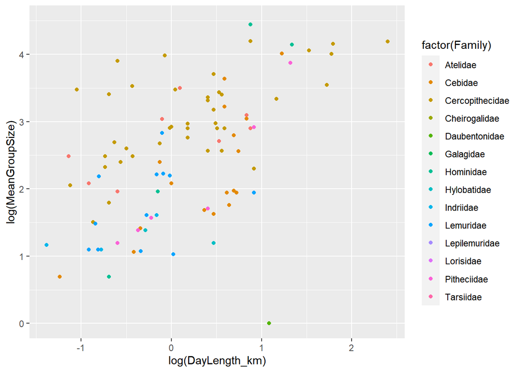

```r
  s+geom_point(aes(color=factor(Family)), na.rm = TRUE)
```

#Now Plot BSD vs Canine Dimorphism. Log transform the data.

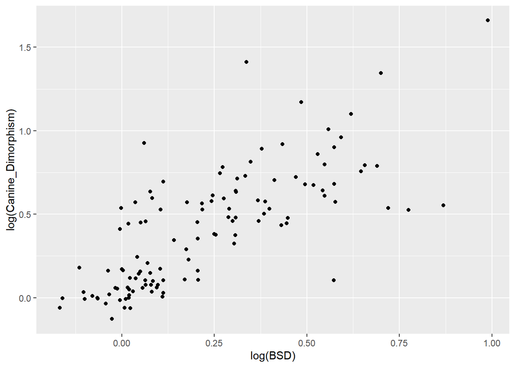

```r
s<-ggplot(data=d, aes(x=log(BSD), y=log(Canine_Dimorphism)))
s+geom_point(na.rm = TRUE)
```

#Plot BSD vs canine dimorphism separated by family.

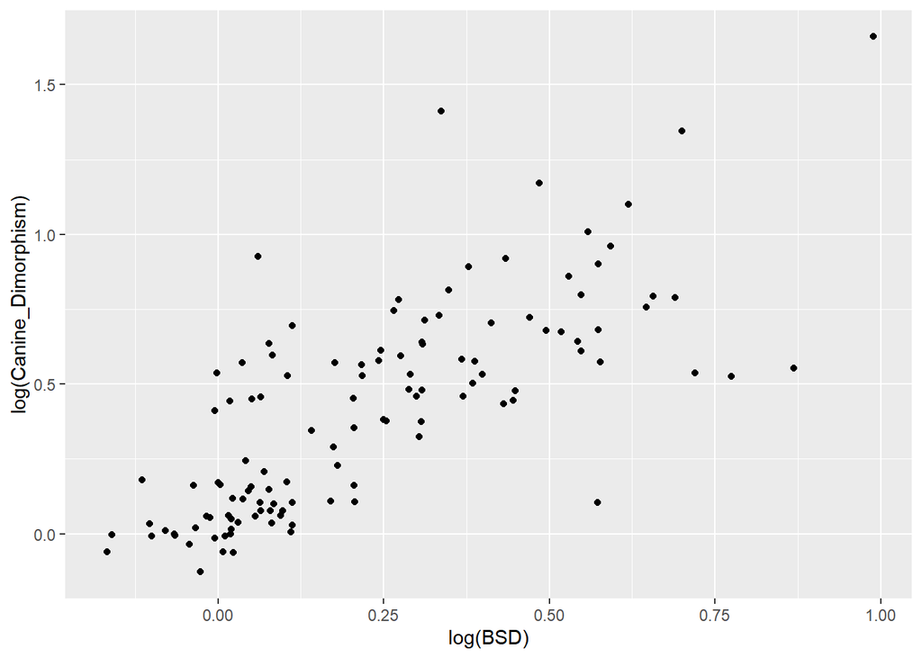

```r
s<-ggplot(data=d, aes(x=log(BSD), y=log(Canine_Dimorphism)))
  s+geom_point(na.rm = TRUE)
```

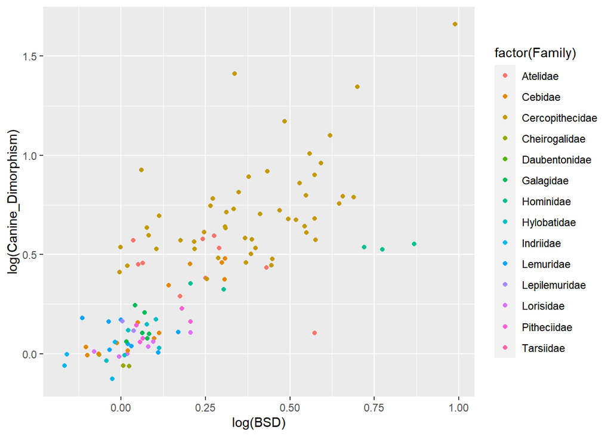

```r
  s+geom_point(aes(color=factor(Family)), na.rm = TRUE)
```

Taxa with greater BSD also have greater canine dimorphism. Cercopithecidae is a good example of this.

#Create a new column for diet strategy. Frugivore = fruit >50% of diet Folivore = Leaves >50% of diet Omnivore = Neither of above is true

```r
d<-mutate(d, diet = case_when(Fruit >= 50 ~ "frugivore", Leaves >= 50 ~ "folivore", Fruit < 50 & Leaves < 50 ~ "omnivore"))
```

#Make Boxplots!! Want to look at how group size compares among diets.

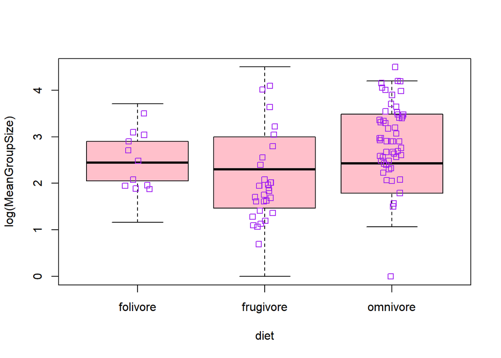

```r
boxplot(data=d, log(MeanGroupSize) ~ diet, col="pink")
stripchart(data=d, log(MeanGroupSize) ~ Family, method = "jitter", col="purple", vertical = TRUE, add = TRUE)
```

Frugivores live in smaller groups than folivores.

#Now manipulate the data frame in one line of code… Add column “Binomial” Trim data down to only Binomial, Family, Brain size species mean, and body mass male mean. Group by family. Calculate average brain size and male body mass per family. Arrange by increasing average brain size

```r
s<-d%>% mutate(Binomial=paste0(Genus, " ", Species))%>%
  select("Binomial","Family","Brain_Size_Species_Mean","Body_mass_male_mean")%>%
  group_by(Family)%>%
  mutate(Avg_Brain_Size=mean(Brain_Size_Species_Mean, na.rm=TRUE),Avg_Male_Body_Mass=mean(Body_mass_male_mean, na.rm=TRUE))%>%
  arrange(Avg_Brain_Size)
s
```

```
## # A tibble: 213 × 6
## # Groups:   Family [14]
##    Binomial     Family Brain_Size_Species_M…¹ Body_mass_male_mean Avg_Brain_Size
##    <chr>        <chr>                   <dbl>               <dbl>          <dbl>
##  1 Tarsius ban… Tarsi…                   3.16                 128           3.26
##  2 Tarsius den… Tarsi…                  NA                     NA           3.26
##  3 Tarsius syr… Tarsi…                   3.36                 134           3.26
##  4 Cheirogaleu… Cheir…                   5.81                 438           4.04
##  5 Cheirogaleu… Cheir…                   2.6                  140           4.04
##  6 Microcebus … Cheir…                   1.63                  63           4.04
##  7 Microcebus … Cheir…                  NA                     31           4.04
##  8 Microcebus … Cheir…                   1.72                  43           4.04
##  9 Mirza coque… Cheir…                   5.8                  311           4.04
## 10 Phaner furc… Cheir…                   6.68                 328           4.04
## # ℹ 203 more rows
## # ℹ abbreviated name: ¹Brain_Size_Species_Mean
## # ℹ 1 more variable: Avg_Male_Body_Mass <dbl>
```